# Resultados UCLUST para secuencias del Genoma con id= 97 y 98%

### UCLUST con id = 97 y 98%

Estas graficas representan las secuencias de Genoma completo del virus del Dengue analizadas con UCLUST con id= 97 y 98%.

De un total de 3884 datos con genoma completo:

- id 97% : 98 Secuencias disimilares
- id 98% : 205 Secuencias disilares

### Secuencias disimilares al 97%

|  | N_Accesion | gi | Title | Serotype | Genotype | Gene | Size_sequence | Country | Location | Year | Month | lat_country | lon_country | locationtype_country | formatted_country | lat_location | lon_location | locationtype_location | formatted_location | Comments |
| --- | --- | --- | --- | --- | --- | --- | --- | --- | --- | --- | --- | --- | --- | --- | --- | --- | --- | --- | --- | --- |
| 1381 | FJ639670 | 221071158 | Dengue_virus_1_isolate_DENV_1_KH_BID_V1979_2001_complete_genome | DENV_1 | NA | Complete_Genome | 10693 | Cambodia | PHP | 2001 | NA | 12.565679 | 104.990963 | APPROXIMATE | Cambodia | NA | NA | NA | NA | Cambodia_PHP_cell_supernatant_2001_passage_history_AP61_passage_number_unknown_cohort_population_Dengue_Surveillance |
| 1293 | FJ461303 | 217302380 | Dengue_virus_1_isolate_DENV_1_VN_BID_V971_2007_complete_genome | DENV_1 | NA | Complete_Genome | 10691 | Viet Nam | South Viet Nam | 2007 | NA | 14.058324 | 108.277199 | APPROXIMATE | Vietnam | 14.058324 | 108.277199 | APPROXIMATE | Vietnam | Viet_Nam_South_plasma_2007_cohort_population_FG |
| 1124 | FJ384655 | 211908643 | Dengue_virus_1_isolate_DF01_HUB01021093_complete_genome | DENV_1 | NA | Complete_Genome | 10735 | Brazil | NA | NA | NA | -14.235004 | -51.925280 | APPROXIMATE | Brazil | NA | NA | NA | NA | Brazil_plasma |
| 2819 | KF289073 | 613790718 | Dengue_virus_1_isolate_P23086_complete_genome | DENV_1 | NA | Complete_Genome | 10690 | India | NA | 1956 | NA | 20.593684 | 78.962880 | APPROXIMATE | India | NA | NA | NA | NA | India_1956 |
| 2824 | KP723473 | 891070663 | Dengue_virus_1_isolate_DENV1_CN_GZ27_2014_complete_genome | DENV_1 | V | Complete_Genome | 10630 | China | Guangdong | 2014 | NA | 35.861660 | 104.195397 | APPROXIMATE | China | 23.379033 | 113.763283 | APPROXIMATE | Guangdong, China | V_China_Guangdong_2014 |
| 1087 | FJ196847 | 224551981 | Dengue_virus_1_isolate_GD01_97_polyprotein_gene_complete_cds | DENV_1 | NA | Complete_Genome | 10735 | China | Guangzhou | 1997 | NA | 35.861660 | 104.195397 | APPROXIMATE | China | 23.129110 | 113.264385 | APPROXIMATE | Guangzhou, Guangdong, China | China_Guangzhou_Guangdong_Province_cell_culture_from_Aedes_albopictus_cell_line__C6_36__1997 |
| 1086 | FJ196846 | 224551979 | Dengue_virus_1_isolate_GD95_95_polyprotein_gene_complete_cds | DENV_1 | NA | Complete_Genome | 10735 | China | Guangzhou | 1995 | NA | 35.861660 | 104.195397 | APPROXIMATE | China | 23.129110 | 113.264385 | APPROXIMATE | Guangzhou, Guangdong, China | China_Guangzhou_Guangdong_Province_cell_culture_from_Aedes_albopictus_cell_line__C6_36__1995 |
| 1085 | FJ196845 | 224551977 | Dengue_virus_1_isolate_GD03_91_polyprotein_gene_complete_cds | DENV_1 | NA | Complete_Genome | 10735 | China | Guangzhou | 1991 | NA | 35.861660 | 104.195397 | APPROXIMATE | China | 23.129110 | 113.264385 | APPROXIMATE | Guangzhou, Guangdong, China | China_Guangzhou_Guangdong_Province_cell_culture_from_Aedes_albopictus_cell_line__C6_36__1991 |
| 1082 | FJ196842 | 224551971 | Dengue_virus_1_isolate_GD66_03_polyprotein_gene_complete_cds | DENV_1 | NA | Complete_Genome | 10735 | China | Guangzhou | 2003 | NA | 35.861660 | 104.195397 | APPROXIMATE | China | 23.129110 | 113.264385 | APPROXIMATE | Guangzhou, Guangdong, China | China_Guangzhou_Guangdong_Province_cell_culture_from_Aedes_albopictus_cell_line__C6_36__2003 |
| 2265 | GU131863 | 263612994 | Dengue_virus_1_isolate_DENV_1_BR_BID_V3490_2008_complete_genome | DENV_1 | NA | Complete_Genome | 10532 | Brazil | Sao Paulo | 2008 | NA | -14.235004 | -51.925280 | APPROXIMATE | Brazil | -23.550520 | -46.633309 | APPROXIMATE | São Paulo, State of São Paulo, Brazil | Brazil_Sao_Paulo_serum_2008_cohort_population_RP_BR |

[output cut: 88 more lines]

**Tabla 1.** Datos de secuencias del genoma 97% disimilares.

|  | N_Accesion | gi | Title | Serotype | Genotype | Gene | Size_sequence | Country | Location | Year | Month | lat_country | lon_country | locationtype_country | formatted_country | lat_location | lon_location | locationtype_location | formatted_location | Comments |
| --- | --- | --- | --- | --- | --- | --- | --- | --- | --- | --- | --- | --- | --- | --- | --- | --- | --- | --- | --- | --- |
| 1381 | FJ639670 | 221071158 | Dengue_virus_1_isolate_DENV_1_KH_BID_V1979_2001_complete_genome | DENV_1 | NA | Complete_Genome | 10693 | Cambodia | PHP | 2001 | NA | 12.565679 | 104.990963 | APPROXIMATE | Cambodia | NA | NA | NA | NA | Cambodia_PHP_cell_supernatant_2001_passage_history_AP61_passage_number_unknown_cohort_population_Dengue_Surveillance |
| 3784 | JF937615 | 332959477 | Dengue_virus_1_isolate_DENV_1_VN_BID_V4062_2008_complete_genome | DENV_1 | NA | Complete_Genome | 10448 | Viet Nam | South Viet Nam | 2008 | NA | 14.058324 | 108.277199 | APPROXIMATE | Vietnam | 14.058324 | 108.277199 | APPROXIMATE | Vietnam | Viet_Nam_South_plasma_2008_cohort_population_MD |
| 1293 | FJ461303 | 217302380 | Dengue_virus_1_isolate_DENV_1_VN_BID_V971_2007_complete_genome | DENV_1 | NA | Complete_Genome | 10691 | Viet Nam | South Viet Nam | 2007 | NA | 14.058324 | 108.277199 | APPROXIMATE | Vietnam | 14.058324 | 108.277199 | APPROXIMATE | Vietnam | Viet_Nam_South_plasma_2007_cohort_population_FG |
| 1124 | FJ384655 | 211908643 | Dengue_virus_1_isolate_DF01_HUB01021093_complete_genome | DENV_1 | NA | Complete_Genome | 10735 | Brazil | NA | NA | NA | -14.235004 | -51.925280 | APPROXIMATE | Brazil | NA | NA | NA | NA | Brazil_plasma |
| 2810 | FJ898396 | 228540033 | Dengue_virus_1_isolate_DENV_1_VN_BID_V2858_2006_complete_genome | DENV_1 | NA | Complete_Genome | 10719 | Viet Nam | South Viet Nam | 2006 | NA | 14.058324 | 108.277199 | APPROXIMATE | Vietnam | 14.058324 | 108.277199 | APPROXIMATE | Vietnam | Viet_Nam_South_plasma_2006_cohort_population_MD |
| 1114 | FJ373297 | 209976517 | Dengue_virus_1_isolate_DENV_1_VN_BID_V1647_2007_complete_genome | DENV_1 | NA | Complete_Genome | 10690 | Viet Nam | South Viet Nam | 2007 | NA | 14.058324 | 108.277199 | APPROXIMATE | Vietnam | 14.058324 | 108.277199 | APPROXIMATE | Vietnam | Viet_Nam_South_plasma_2007_cohort_population_FG |
| 1147 | FJ410175 | 209976601 | Dengue_virus_1_isolate_DENV_1_US_BID_V2095_1994_complete_genome | DENV_1 | NA | Complete_Genome | 10690 | Puerto Rico | NA | 1994 | NA | 18.220833 | -66.590149 | APPROXIMATE | Puerto Rico | NA | NA | NA | NA | USA_Puerto_Rico_cell_supernatant_1994_passage_history_C6_36_1_cohort_population_Puerto_Rico |
| 1099 | FJ205874 | 204305639 | Dengue_virus_1_isolate_DENV_1_US_BID_V1743_1995_complete_genome | DENV_1 | NA | Complete_Genome | 10690 | Puerto Rico | NA | 1995 | NA | 18.220833 | -66.590149 | APPROXIMATE | Puerto Rico | NA | NA | NA | NA | USA_Puerto_Rico_cell_supernatant_1995_passage_history_C6_36_1_cohort_population_Puerto_Rico |
| 2819 | KF289073 | 613790718 | Dengue_virus_1_isolate_P23086_complete_genome | DENV_1 | NA | Complete_Genome | 10690 | India | NA | 1956 | NA | 20.593684 | 78.962880 | APPROXIMATE | India | NA | NA | NA | NA | India_1956 |
| 2824 | KP723473 | 891070663 | Dengue_virus_1_isolate_DENV1_CN_GZ27_2014_complete_genome | DENV_1 | V | Complete_Genome | 10630 | China | Guangdong | 2014 | NA | 35.861660 | 104.195397 | APPROXIMATE | China | 23.379033 | 113.763283 | APPROXIMATE | Guangdong, China | V_China_Guangdong_2014 |

[output cut: 195 more lines]

**Tabla 2.** Datos de secuencias del genoma 98% disimilares.

### Serotipos

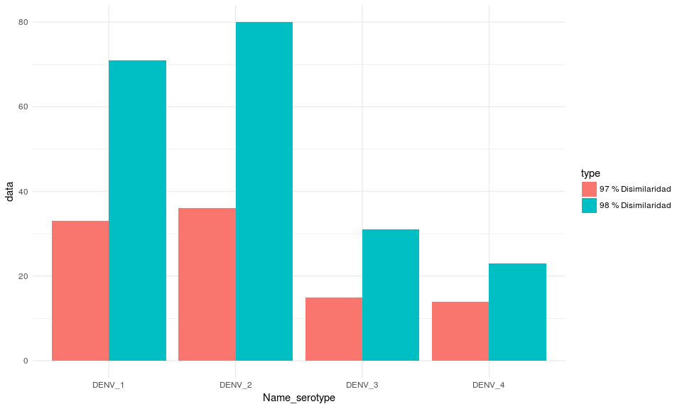

**Figura 1.** Numero de datos por serotipos para las secuencias Disimilares al 97 y 98%

### Paises

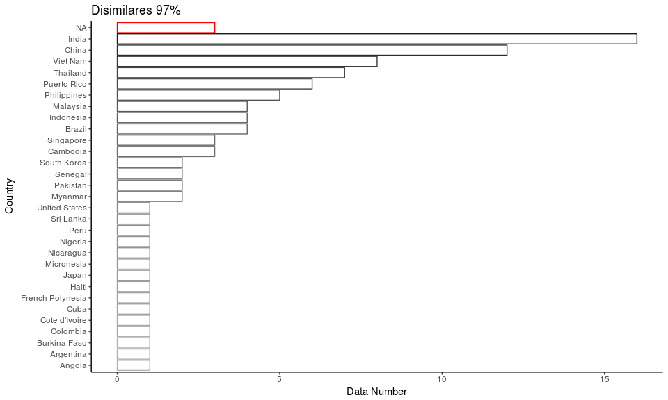

**Figura 2.** Paises para secuencias de Genoma 97% disimilares.

[1] Cambodia Viet Nam Brazil India China  
[6] Myanmar Thailand United States Malaysia Angola  
[11] Cote d’Ivoire Micronesia French Polynesia Philippines  
[16] South Korea Japan Argentina Burkina Faso Puerto Rico  
[21] Peru Cuba Singapore Nigeria Senegal  
[26] Indonesia Nicaragua Pakistan Sri Lanka Haiti  
[31] Colombia

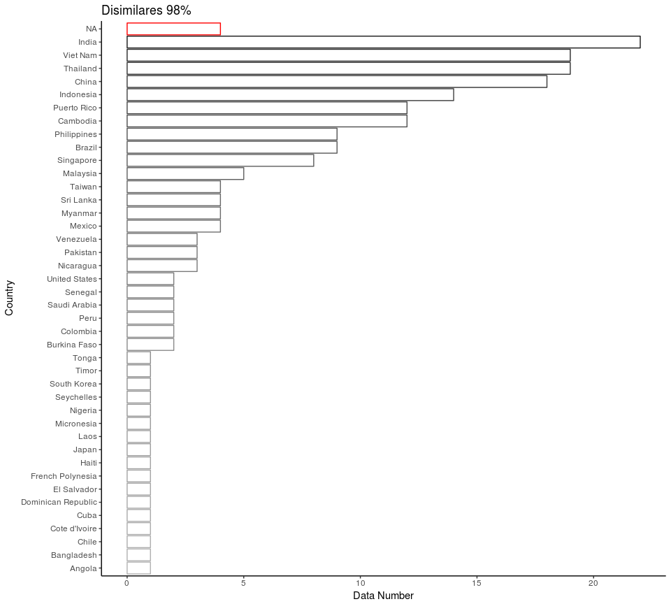

**Figura 3.** Paises para secuencias de Genoma 98% disimilares.

[1] Cambodia Viet Nam Brazil Puerto Rico  
[5] India China Venezuela Sri Lanka  
[9] Myanmar Indonesia Thailand Malaysia  
[13] United States Chile Philippines Mexico  
[17] Taiwan Angola Laos Singapore  
[21] Cote d’Ivoire Micronesia Seychelles  
[25] El Salvador Nicaragua Saudi Arabia Colombia  
[29] Burkina Faso Peru Cuba Pakistan  
[33] Dominican Republic Nigeria Senegal South Korea  
[37] Tonga Bangladesh Timor Japan  
[41] Haiti French Polynesia

[1] “Venezuela” “Chile” “Mexico” “Taiwan”  
[5] “Laos” “Seychelles” “El Salvador” “Saudi Arabia”  
[9] “Dominican Republic” “Tonga” “Bangladesh” “Timor”

### Mapa-Mundi: Numero de casos reportados por paises

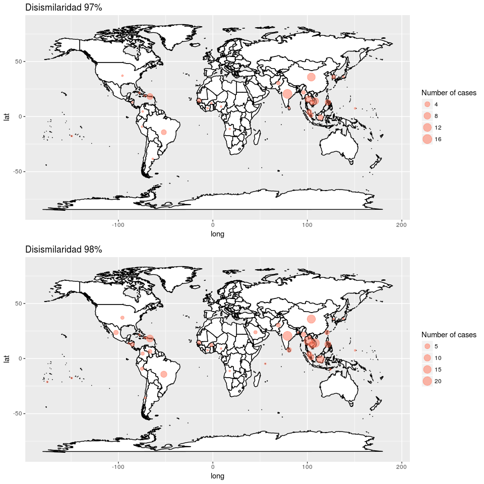

**Figura 4.** Numero de casos reportados por paises.

### Mapa-mundi: Serotipos por paises

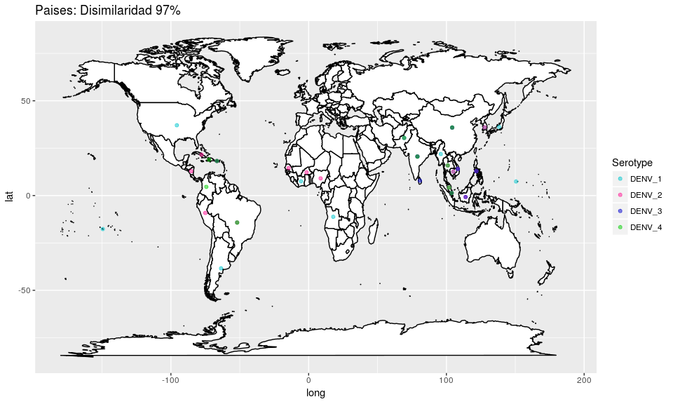

**Figura 5.** Distribucion de los serotipos por paises para secuencias 97% disimilares.

[figure not shown]

**Figura 6.** Distribucion de los serotipos por paises para secuencias 98% disimilares.

### Localidades: Disimilaridad 97%

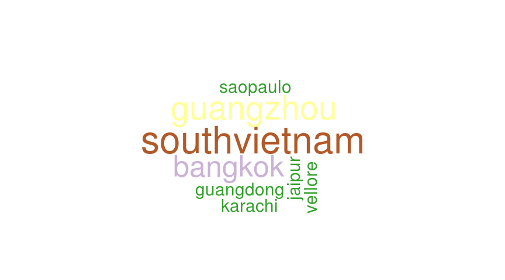

**Figura 7.** Nube de localidades para secuecias del Genoma 97% Disimilares.

### Localidades: Disimilaridad 98%

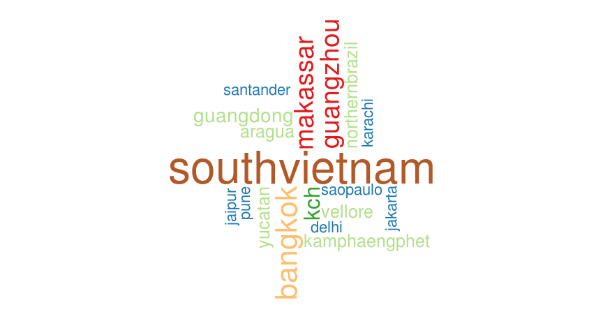

**Figura 8.** Nube de localidades para secuecias del Genoma 98% Disimilares.

### Mapa-mundi localidades 97% Disimilaridad

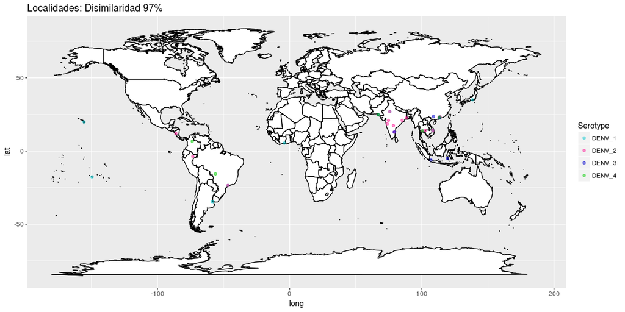

**Figura 9.** Localidades de secuencias del genoma 97% disimilares.

### Mapa-mundi localidades 98% Disimilaridad

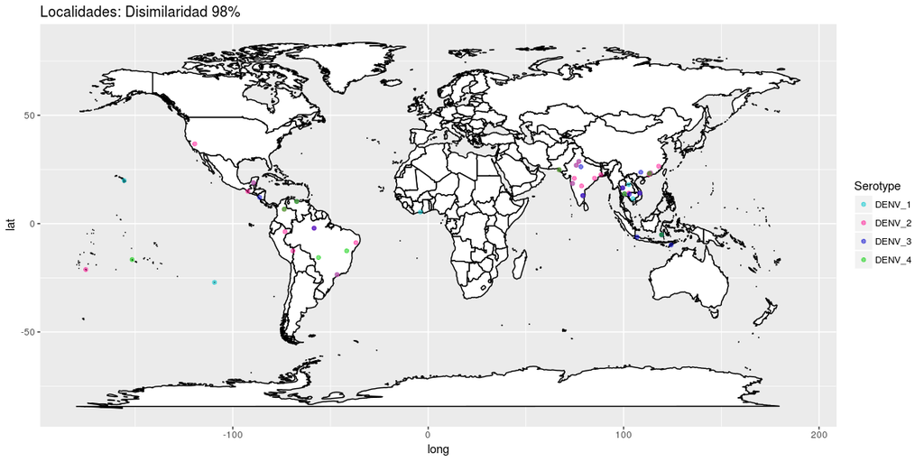

**Figura 10.** Localidades de secuencias del genoma 98% disimilares.

### Años: Disimilaridad 97%

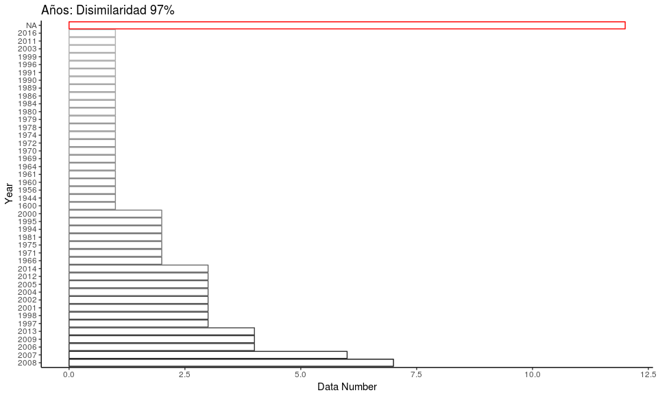

**Figura 11.** Años registrados para casos con secuencias 97% disimilares.

1600 1944 1956 1960 1961 1964 1966 1969 1970 1971 1972 1974 1975 1978 1979 1980 1981 1984 1986 1989 1990 1991 1994 1995 1996 1997 1998 1999 2000 2001 2002 2003 2004 2005 2006 2007 2008 2009 2011 2012 2013 2014 2016

### Años: Disimilaridad 98%

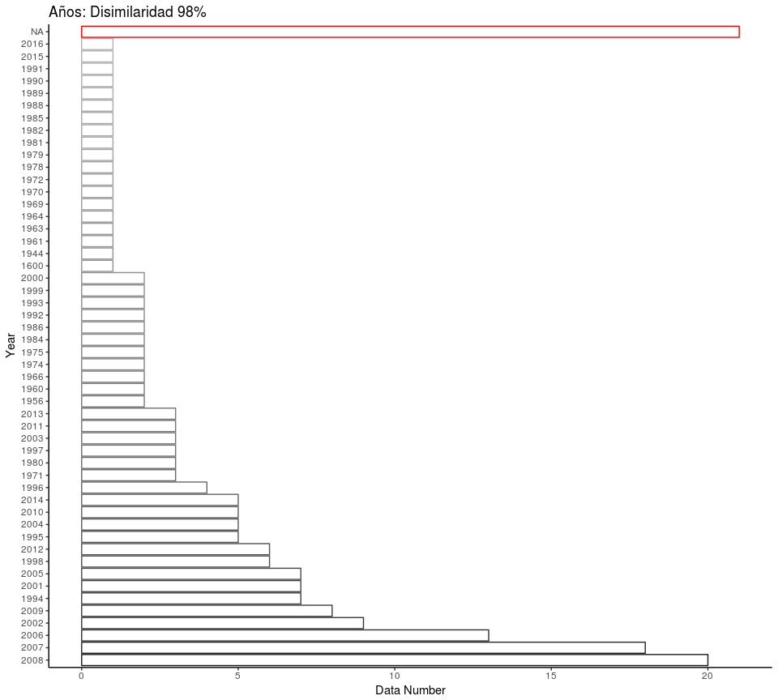

**Figura 12.** Años registrados para casos con secuencias 98% disimilares.

1600 1944 1956 1960 1961 1963 1964 1969 1970 1971 1972 1974 1975 1978 1979 1980 1981 1982 1984 1985 1986 1988 1989 1990 1991 1992 1993 1994 1995 1996 1997 1998 1999 2000 2001 2002 2003 2004 2005 2006 2007 2008 2009 2010 2011 2012 2013 2014 2015 2016

### Frecuencia de los años reportados por cada pais: Disimilaridad 97%

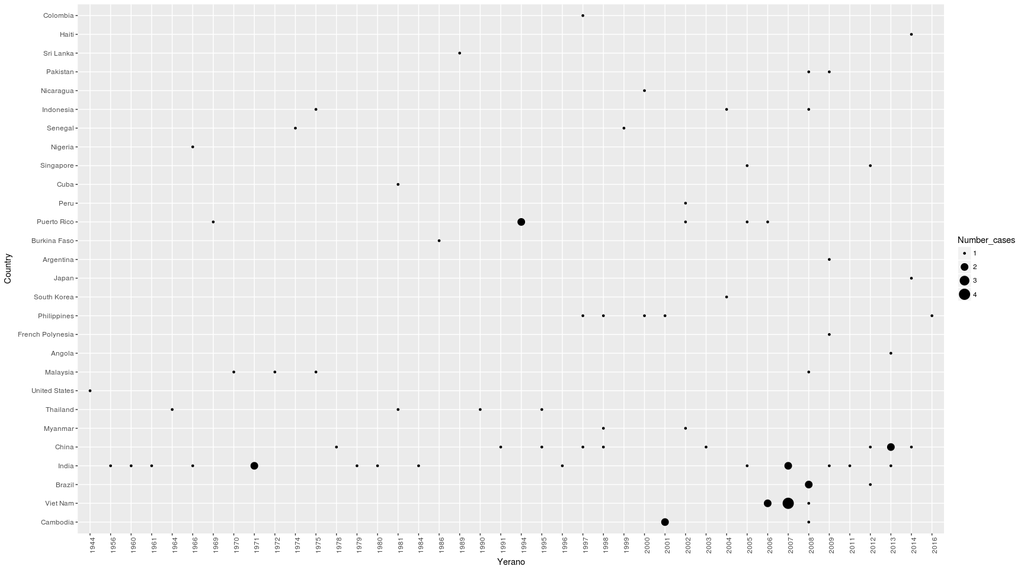

**Figura 13.** Frecuencia de los años reportados para cada pais para secuencias 97% disimilaridad.

### Frecuencia de los años reportados por cada pais: Disimilaridad 98%

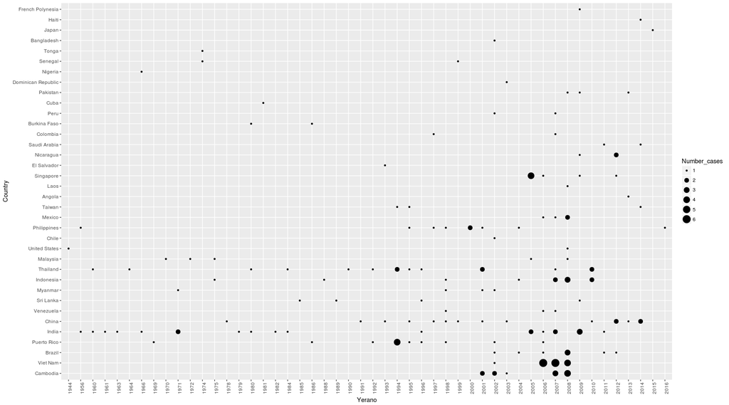

**Figura 14.** Frecuencia de los años reportados para cada pais para secuencias 98% disimilaridad.

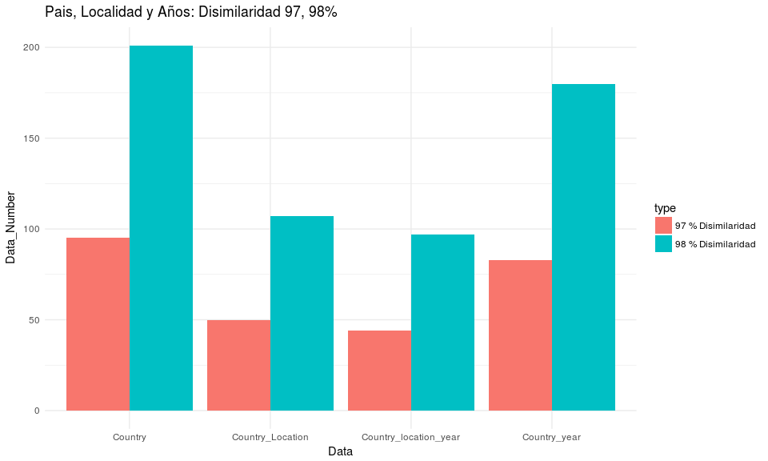

**Figura 15.** Frecuencia de los datos con disimilaridad del 97 y 98% que contienen: 1. Pais, 2. Pais y Localidad, 3. Pais, Localidad y año, 4. Pais y año.